# Math&146 Lab #5

N. Paterno

This lab will be brief compared to our last few. We will look at a few different ways to plot our data to determine its shape as either normal, skewed left or skewed right.

We’ll be using the *speed_gender_height* data set from the *openintro* package. Let’s see the data.

```r
glimpse(speed_gender_height)
```

```
## Rows: 1,325
## Columns: 3
## $ speed  <int> 85, 40, 87, 110, 110, 120, 90, 90, 80, 95, 110, 90, 110, 70,...
## $ gender <fct> female, male, female, female, male, female, female, female, ...
## $ height <dbl> 69, 71, 64, 60, 70, 61, 65, 65, 61, 69, 63, 72, 70, 68, 63, ...
```

Here we have a data frame that includes a person’s biological gender, height and the maximum speed they have personally driven a car. For the examples I will focus on the *height* variable.

## Cleaning the Data

To clean the data, I’ll remove observations where a height wasn’t reported.

```r
plot_data <- speed_gender_height %>%
  na.omit()
```

## Visuallizing Shape

We’ll look at three different plots that can help us visually determine the shape of our data: histogram, frequency polygon and a density curve.

### Histogram

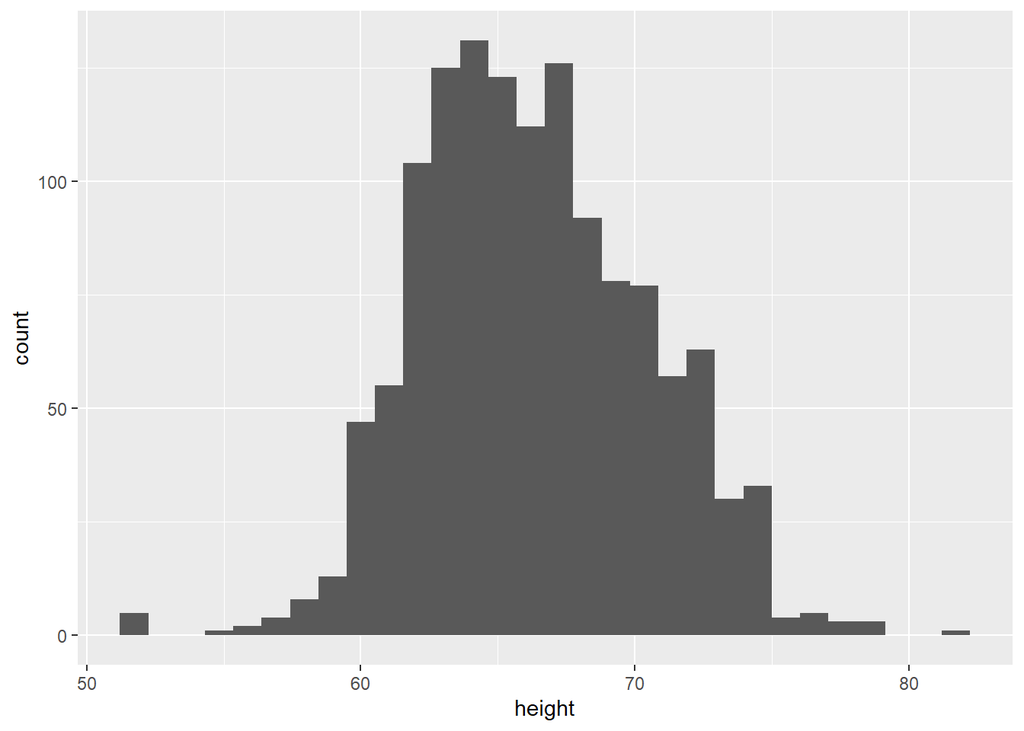

```r
ggplot(plot_data,
       aes(height))+
  geom_histogram()
```

It appears that our data is approximately normal (bell shaped).

### Frequency Polygon

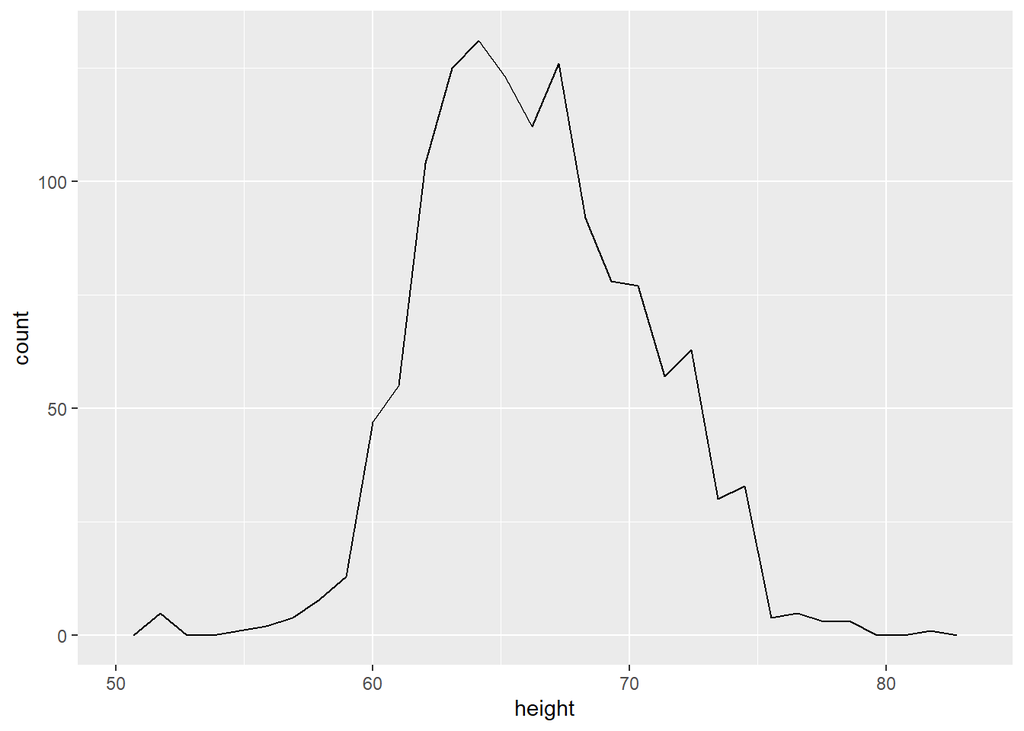

```r
ggplot(plot_data,
       aes(height))+
  geom_freqpoly()
```

While the curve is not smooth, it does show that the data is approximately normal.

### Density Curve

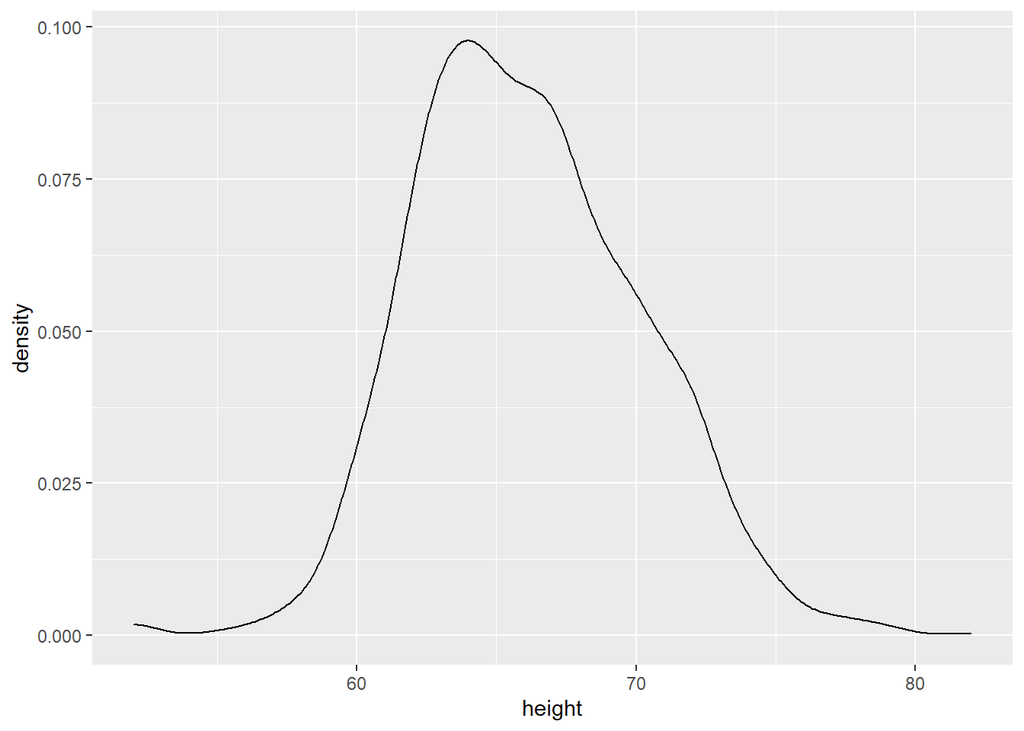

```r
ggplot(plot_data,
       aes(height))+
  geom_density()
```

## Assignment

In a script file:

1. Clean the data to remove any observations that did not have a reported speed.
2. Create a histogram, frequency polygon and density curve for speed using the cleaned data.

Save your work in a script file called: LastName_lab5. For example, my assignment file would be Paterno_lab5.R

## Extra Material

As with the last lab, we’ll go a bit further to see if shape is independent of gender.

We can do this using a *facet_wrap* which will create a separate plot for each gender.

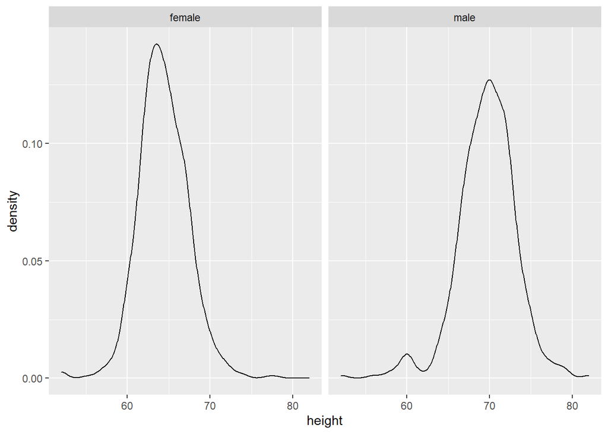

```r
ggplot(plot_data,
       aes(height))+
  geom_density()+
  facet_wrap(~gender)
```

It appears that the data is still approximately normal when we focus on individual genders.

Another way we could do this is using color.

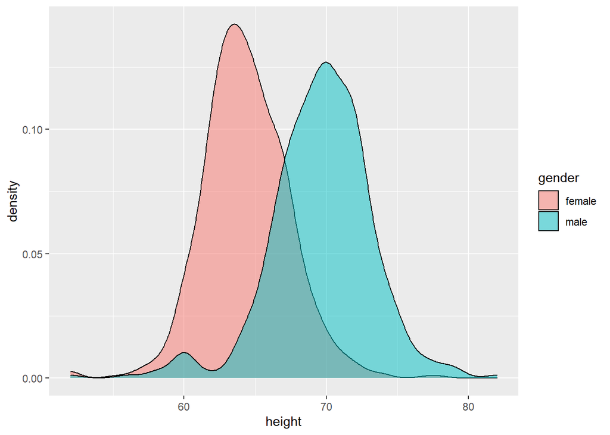

```r
ggplot(plot_data,
       aes(height,
           fill = gender))+
  geom_density(alpha = 0.5)
```

The *alpha* argument specifies how see-through the plot is. Closer to 1 is opaque, closer to 0 is transparent.